# Normalization Comparison

D. Ford Hannum

2023-07-05

# 1 Introduction

This file accompanies the Vizgen Analysis Guides: Normalzation.

Here we will compare the differences between three normalization methods.

1. “Standard”
2. “Seurat SCT”
3. “Spatial”

# 2 Loading packages

```r
knitr::opts_chunk$set(echo = TRUE)
library(Seurat) # to run normalizaiton methods
# install.packages('aws.s3')
library(aws.s3) # to access data from a public AWS bucket
```

```r
library(data.table) # data processing library
library(ggplot2) # package to make visualizaitons
```

# 3 Loading Data

Here we are going to use publicaly available data from a MERSCOPE mouse brain sample.

```r
# # The path to the s3 bucket
# s3_bucket_path = "s3://vzg-vzg-showcase-data/Mouse_Brain_Showcase_232/Slice-1_Replicate_1"
#
# # Verifying the bucket exists
# bucket_exists(bucket = s3_bucket_path,
#               region = 'us-east-1')[1]
#
# get_bucket_df(bucket = s3_bucket_path,
#               region = 'us-east-1')
```

For our purposes we only need cell_by_gene.csv and cell_metadata.csv files.

```r
md <- fread('https://vzg-vzg-showcase-data.s3.amazonaws.com/Mouse_Brain_Showcase_232/Slice-1_Replicate-1/cell_metadata.csv',
               header = T, data.table = FALSE)

counts <- fread('https://vzg-vzg-showcase-data.s3.amazonaws.com/Mouse_Brain_Showcase_232/Slice-1_Replicate-1/cell_by_gene.csv',
               header = T, data.table = FALSE)

rownames(md) <- md$EntityID
rownames(counts) <- counts$cell
counts <- counts[,-1] # removing cells as a column so we have a data frame of only counts
blanks <- counts[,grepl('Blank', colnames(counts))]
counts <- counts[,!grepl('Blank', colnames(counts))] # removing blanks

counts <- t(counts)

counts[1:5,1:5]
```

```
##       121919181900000000 121919181900000001 121919181900000002
## Oxgr1                  0                  0                  0
## Htr1a                  0                  0                  0
## Htr1b                  0                  0                  0
## Htr1d                  0                  0                  0
## Htr1f                  0                  0                  0
##       121919181900000003 121919181900000004
## Oxgr1                  0                  0
## Htr1a                  0                  6
## Htr1b                  0                  0
## Htr1d                  0                  0
## Htr1f                  0                  0
```

```r
table(rownames(md) == rownames(counts)) # making sure the data frames align
```

```
##
## FALSE
## 78273
```

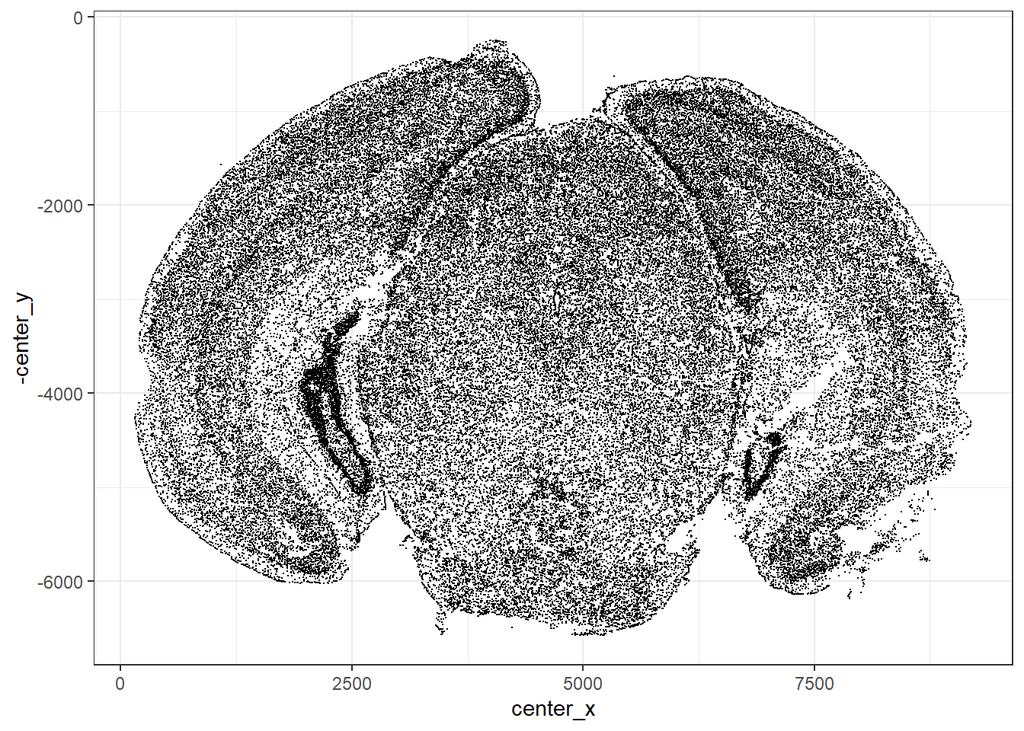

```r
ggplot(md, aes(x = center_x, y = -center_y)) +
  geom_point(size = .1) + theme_bw()
```

## 3.1 Subsetting for testing

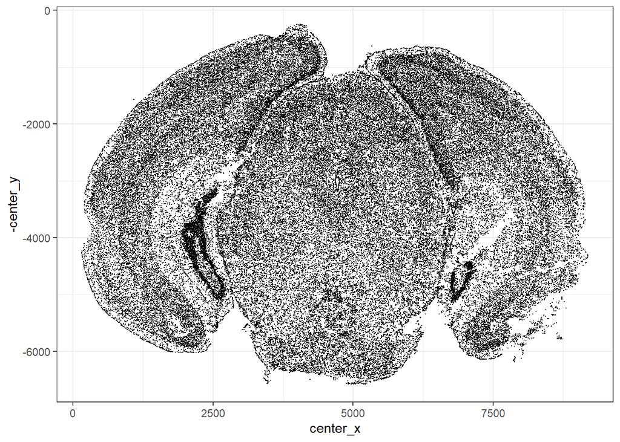

```r
# md <- md[md$center_x < 2500 & md$center_y < 3000,]

ggplot(md, aes(x = center_x, y = -center_y)) +
  geom_point(size = .1) + theme_bw()
```

```r
dim(md)
```

```
## [1] 78273    13
```

```r
counts <- counts[,rownames(md)]
dim(counts)
```

```
## [1]   483 78273
```

# 4 Seurat Workflow

Using Seurat

```r
spat <- CreateSeuratObject(counts = counts,
                           assay = 'RNA',
                           meta.data = md)

spat
```

```
## An object of class Seurat
## 483 features across 78273 samples within 1 assay
## Active assay: RNA (483 features, 0 variable features)
```

## 4.1 Filtering

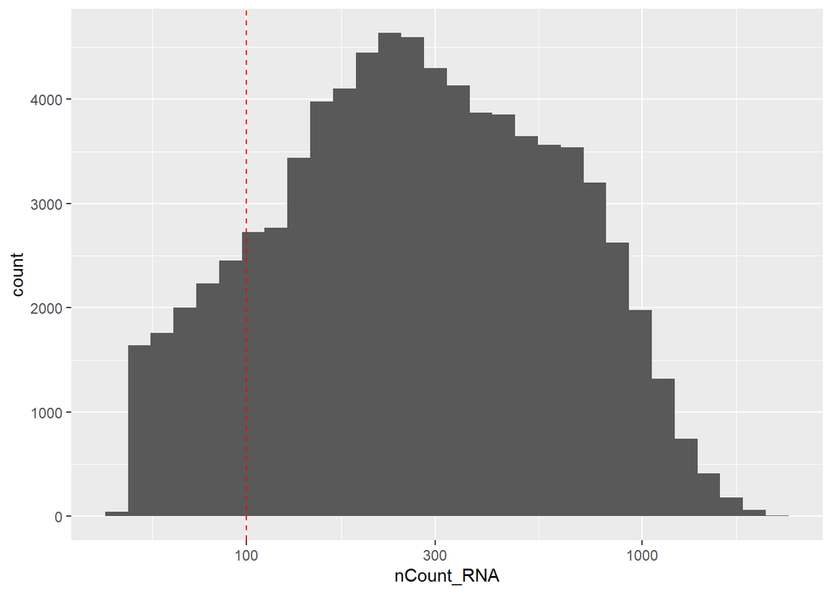

```r
ggplot(spat@meta.data, aes(x = nCount_RNA)) +
  geom_histogram() +
  scale_x_log10() +
  geom_vline(xintercept = 100, linetype = 2, colour = 'red')
```

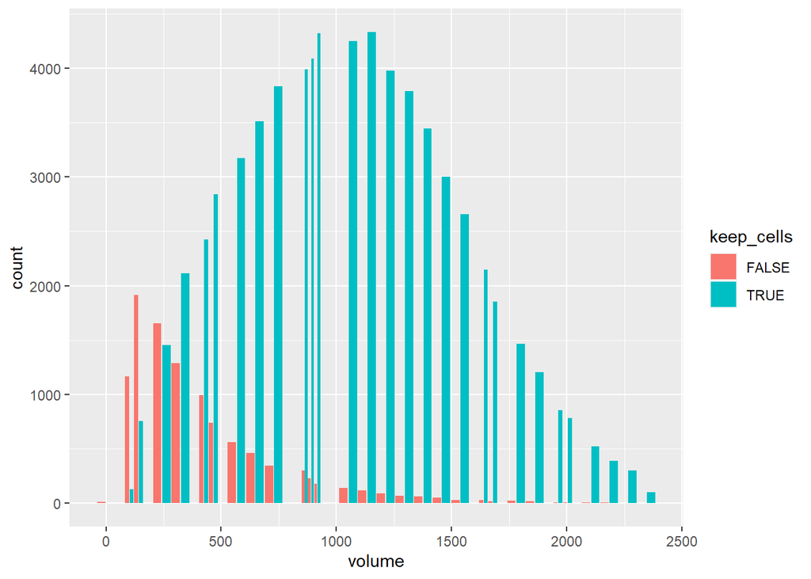

```r
spat$keep_cells <- spat$nCount_RNA >= 100

ggplot(spat@meta.data, aes(x = volume, fill = keep_cells)) +
  geom_histogram(position = position_dodge2())
```

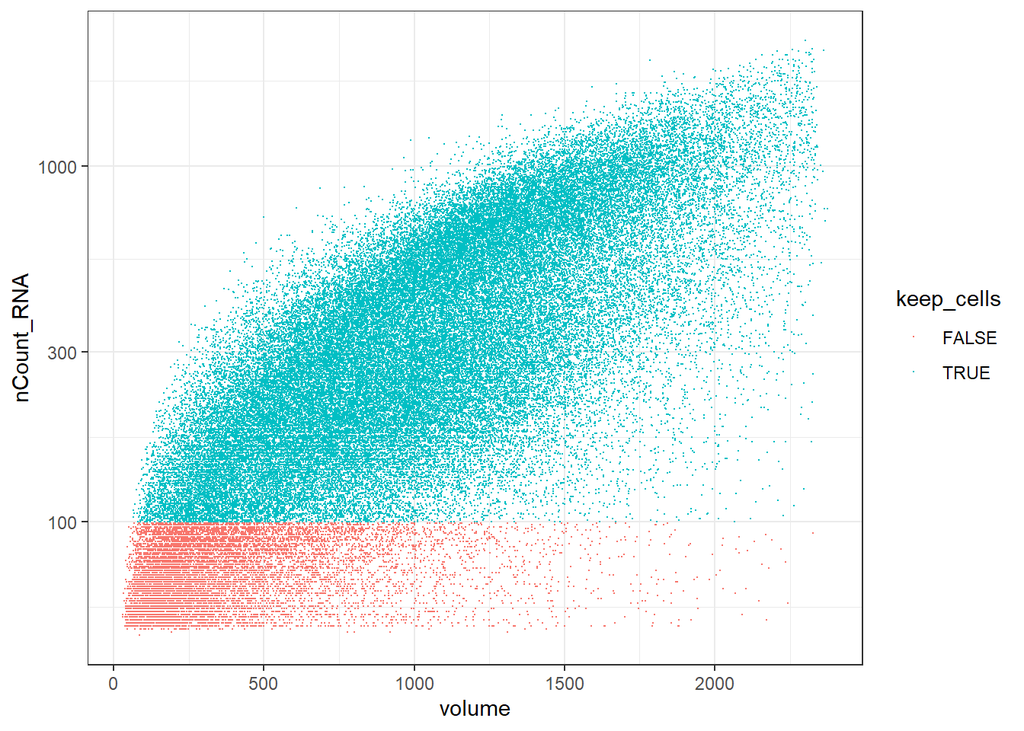

```r
ggplot(spat@meta.data, aes(x = volume, y = nCount_RNA,
                           colour = keep_cells)) +
  geom_point(size = .1) +
  theme_bw() +
  scale_y_log10()
```

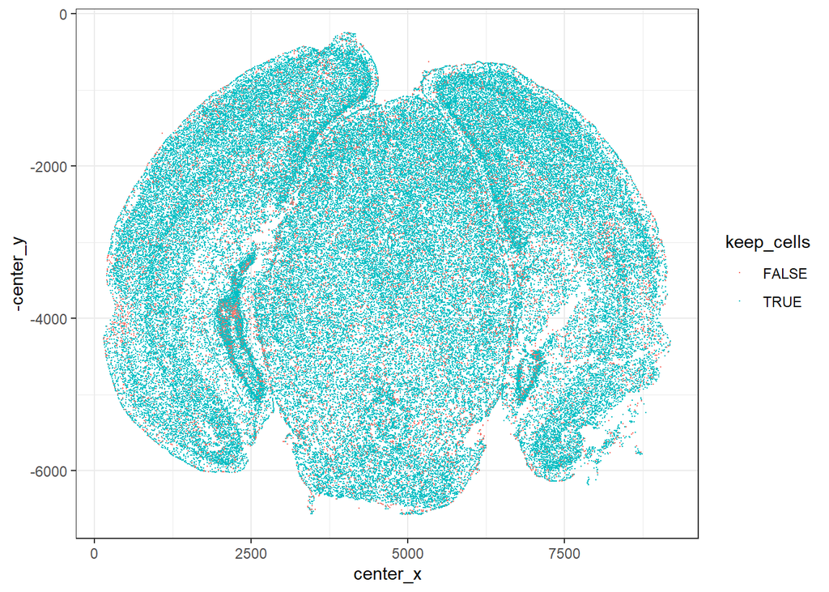

```r
ggplot(spat@meta.data, aes(x = center_x, y = -center_y,
                           colour = keep_cells)) +
  geom_point(size = .1) +
  theme_bw()
```

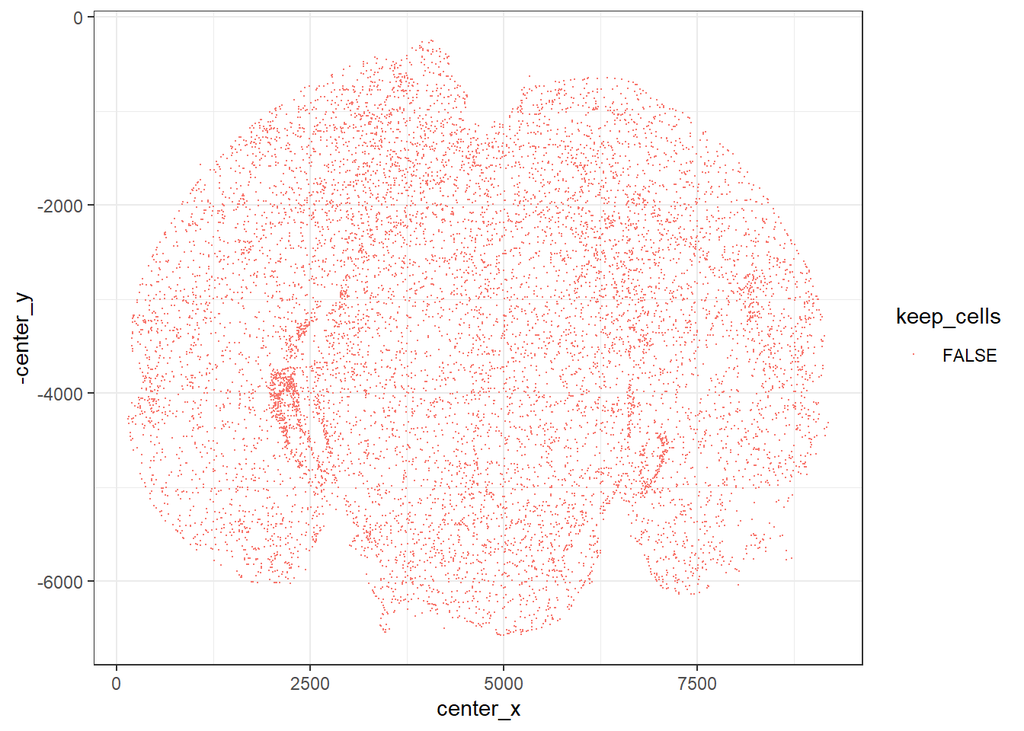

```r
ggplot(spat@meta.data[spat$keep_cells == FALSE,], aes(x = center_x, y = -center_y,
                           colour = keep_cells)) +
  geom_point(size = .1) +
  theme_bw()
```

```r
spat <- subset(spat, nCount_RNA >= 100)
```

# 5 Normalizations

## 5.1 Standard

```r
spat <- NormalizeData(spat, normalization.method = 'LogNormalize',
                      scale.factor =  1e4)
spat <- ScaleData(spat, features = rownames(spat))
spat <- RunPCA(spat, features = rownames(spat), verbose = FALSE)

spat <- FindNeighbors(spat, dims = 1:10)
spat <- FindClusters(spat, resolution = .5)
```

```
## Modularity Optimizer version 1.3.0 by Ludo Waltman and Nees Jan van Eck
##
## Number of nodes: 67729
## Number of edges: 2018918
##
## Running Louvain algorithm...
## Maximum modularity in 10 random starts: 0.9224
## Number of communities: 18
## Elapsed time: 19 seconds
```

```r
spat <- RunUMAP(spat, dims = 1:10)
spat@meta.data[,paste0('std_pca',1:5)] <- spat@reductions$pca@cell.embeddings[,1:5]
spat@meta.data[,paste0('std_umap',1:2)] <- spat@reductions$umap@cell.embeddings
```

## 5.2 SCTransform

```r
spat <- SCTransform(spat, clip.range = c(-10,10), vars.to.regress = 'volume')
```

```
## Calculating cell attributes from input UMI matrix: log_umi
```

```
## Variance stabilizing transformation of count matrix of size 483 by 67729
```

```
## Model formula is y ~ log_umi
```

```
## Get Negative Binomial regression parameters per gene
```

```
## Using 481 genes, 5000 cells
```

```
## Found 7 outliers - those will be ignored in fitting/regularization step
```

```
## Second step: Get residuals using fitted parameters for 483 genes
```

```
## Computing corrected count matrix for 483 genes
```

```
## Wall clock passed: Time difference of 15.92867 secs
```

```
## Determine variable features
```

```
## Place corrected count matrix in counts slot
```

```
## Centering data matrix
```

```
## Set default assay to SCT
```

```r
spat <- RunPCA(spat, features = rownames(spat), verbose = FALSE)

spat <- FindNeighbors(spat, dims = 1:10)
spat <- FindClusters(spat, resolution = .5)
```

```
## Modularity Optimizer version 1.3.0 by Ludo Waltman and Nees Jan van Eck
##
## Number of nodes: 67729
## Number of edges: 2125923
##
## Running Louvain algorithm...
## Maximum modularity in 10 random starts: 0.9364
## Number of communities: 28
## Elapsed time: 18 seconds
```

```r
spat <- RunUMAP(spat, dims = 1:10)
spat@reductions$umap
```

```
## A dimensional reduction object with key UMAP_
##  Number of dimensions: 2
##  Projected dimensional reduction calculated:  FALSE
##  Jackstraw run: FALSE
##  Computed using assay: SCT
```

```r
spat@meta.data[,paste0('sct_pca',1:5)] <- spat@reductions$pca@cell.embeddings[,1:5]
spat@meta.data[,paste0('sct_umap',1:2)] <- spat@reductions$umap@cell.embeddings
```

## 5.3 Spatial -volume

Going to “hack” Seurat to do this

```r
transcripts_per_volume <- function(x){
  x[1:483] /x[484] * 250
}

# w <- apply(p,2,transcripts_per_volume)
# tail(w)
```

```r
spat[['tpv']] <- spat@assays$RNA
DefaultAssay(spat) <- 'tpv'

tpv <- spat@assays$RNA@counts

# for (i in 1:dim(tpv)[2]){
#   tpv[,i] <- tpv[,i]/spat$volume[i] * 250
# }
tpv <- rbind(tpv,spat$volume)
tpv <- apply(tpv,2,transcripts_per_volume)
spat@assays$tpv@data <- tpv
spat <- ScaleData(spat, features = rownames(spat))
spat <- RunPCA(spat, features = rownames(spat), verbose = FALSE)

spat <- FindNeighbors(spat, dims = 1:10)
spat <- FindClusters(spat, resolution = .5)
```

```
## Modularity Optimizer version 1.3.0 by Ludo Waltman and Nees Jan van Eck
##
## Number of nodes: 67729
## Number of edges: 2202972
##
## Running Louvain algorithm...
## Maximum modularity in 10 random starts: 0.9320
## Number of communities: 21
## Elapsed time: 17 seconds
```

```r
spat <- RunUMAP(spat, dims = 1:10)
spat@meta.data[,paste0('tpv_pca',1:5)] <- spat@reductions$pca@cell.embeddings[,1:5]
spat@meta.data[,paste0('tpv_umap',1:2)] <- spat@reductions$umap@cell.embeddings
```

# 6 Density

Looking at the density of the cells. The “standard” methods adjust for library size, but the TPV (transcripts by volume) method commonly used in FISH data adjusts for volume.

Here we want to see how concordant/similar volume and library size are.

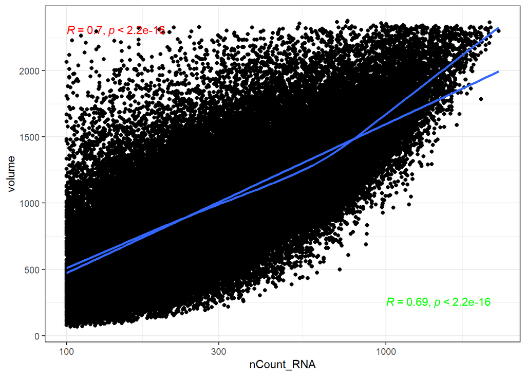

```r
ggplot(spat@meta.data, aes(x = nCount_RNA, y = volume)) +
  geom_point() +
  geom_smooth(method = 'lm', se = F) +
  geom_smooth(se = F) +
  ggpubr::stat_cor(colour = 'red') +
  ggpubr::stat_cor(colour = 'green',label.x = 3, label.y = 250,
                   method = 'spearman') +
  theme_bw() +
  scale_x_log10()
```

# 7 Correlation

```r
x <- spat@assays$RNA@scale.data
y <- spat@assays$tpv@scale.data

cor_list <- c()
for (i in 1:dim(x)[2]){
  if (i %% 500 == 0){print(paste0(i,' out of ',dim(x)[2]))}
  cor_list <- c(cor_list,cor(x[,i],y[,i], method = 'pearson'))
}
```

[output not shown]

[output cut: 120 more lines]

```r
spat$cor_tpv_std <- cor_list
```

```r
x <- spat@assays$SCT@scale.data
y <- spat@assays$tpv@scale.data[rownames(x),]

cor_list <- c()
for (i in 1:dim(x)[2]){
  if (i %% 500 == 0){print(paste0(i,' out of ',dim(x)[2]))}
  cor_list <- c(cor_list,cor(x[,i],y[,i], method = 'pearson'))
}
```

[output not shown]

[output cut: 120 more lines]

```r
spat$cor_tpv_sct <- cor_list
```

```r
x <- spat@assays$SCT@scale.data
y <- spat@assays$RNA@scale.data[rownames(x),]

cor_list <- c()
for (i in 1:dim(x)[2]){
  if (i %% 500 == 0){print(paste0(i,' out of ',dim(x)[2]))}
  cor_list <- c(cor_list,cor(x[,i],y[,i], method = 'pearson'))
}
```

[output not shown]

[output cut: 120 more lines]

```r
spat$cor_RNA_sct <- cor_list
```

```r
rownames(spat)[!(rownames(spat) %in% rownames(x))]
```

```
## character(0)
```

```r
colnames(spat@meta.data)
```

```
##  [1] "orig.ident"           "nCount_RNA"           "nFeature_RNA"
##  [4] "EntityID"             "fov"                  "volume"
##  [7] "center_x"             "center_y"             "min_x"
## [10] "min_y"                "max_x"                "max_y"
## [13] "anisotropy"           "transcript_count"     "perimeter_area_ratio"
## [16] "solidity"             "keep_cells"           "RNA_snn_res.0.5"
## [19] "seurat_clusters"      "std_pca1"             "std_pca2"
## [22] "std_pca3"             "std_pca4"             "std_pca5"
## [25] "std_umap1"            "std_umap2"            "nCount_SCT"
## [28] "nFeature_SCT"         "SCT_snn_res.0.5"      "sct_pca1"
## [31] "sct_pca2"             "sct_pca3"             "sct_pca4"
## [34] "sct_pca5"             "sct_umap1"            "sct_umap2"
## [37] "nCount_tpv"           "nFeature_tpv"         "tpv_snn_res.0.5"
## [40] "tpv_pca1"             "tpv_pca2"             "tpv_pca3"
## [43] "tpv_pca4"             "tpv_pca5"             "tpv_umap1"
## [46] "tpv_umap2"            "cor_tpv_std"          "cor_tpv_sct"
## [49] "cor_RNA_sct"
```

# 8 Recreating Seurat figure

From their SCTransform [paper](https://genomebiology.biomedcentral.com/articles/10.1186/s13059-019-1874-1)

```r
DefaultAssay(spat) <- 'RNA'
```

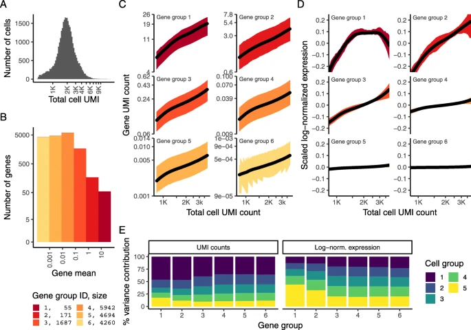

Figure 1

## 8.1 1A

Total UMI histogram

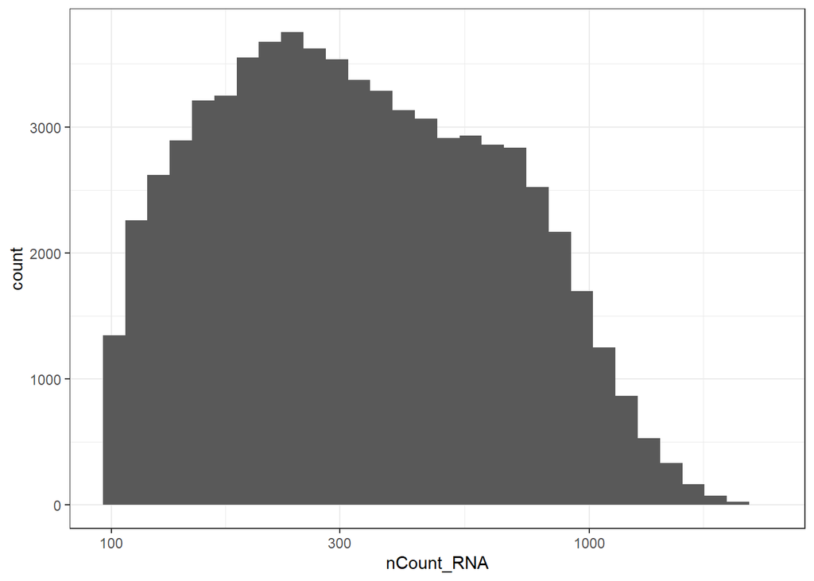

```r
ggplot(spat@meta.data, aes(x = nCount_RNA)) +
  geom_histogram() +
  scale_x_log10() +
  theme_bw()
```

Has a similar normal distribution, but not quite as clean.

## 8.2 1B

Binning mean gene epxression

```r
gene_md <- data.frame('mean' = apply(counts,1,mean),
                      row.names = rownames(spat))
head(gene_md)
```

```
##             mean
## Oxgr1 0.03025309
## Htr1a 0.43739220
## Htr1b 0.40439232
## Htr1d 0.05820653
## Htr1f 0.24832318
## Htr2a 0.25124883
```

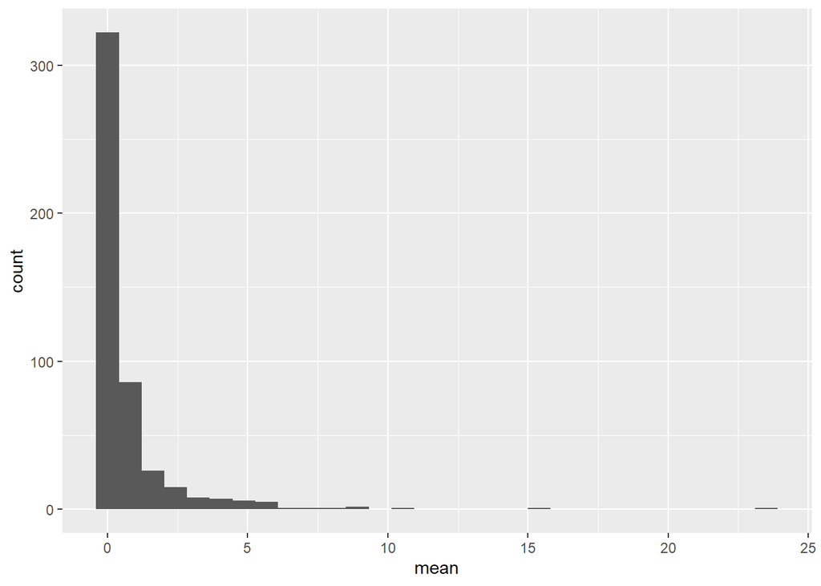

```r
ggplot(gene_md, aes(x = mean)) +
  geom_histogram()
```

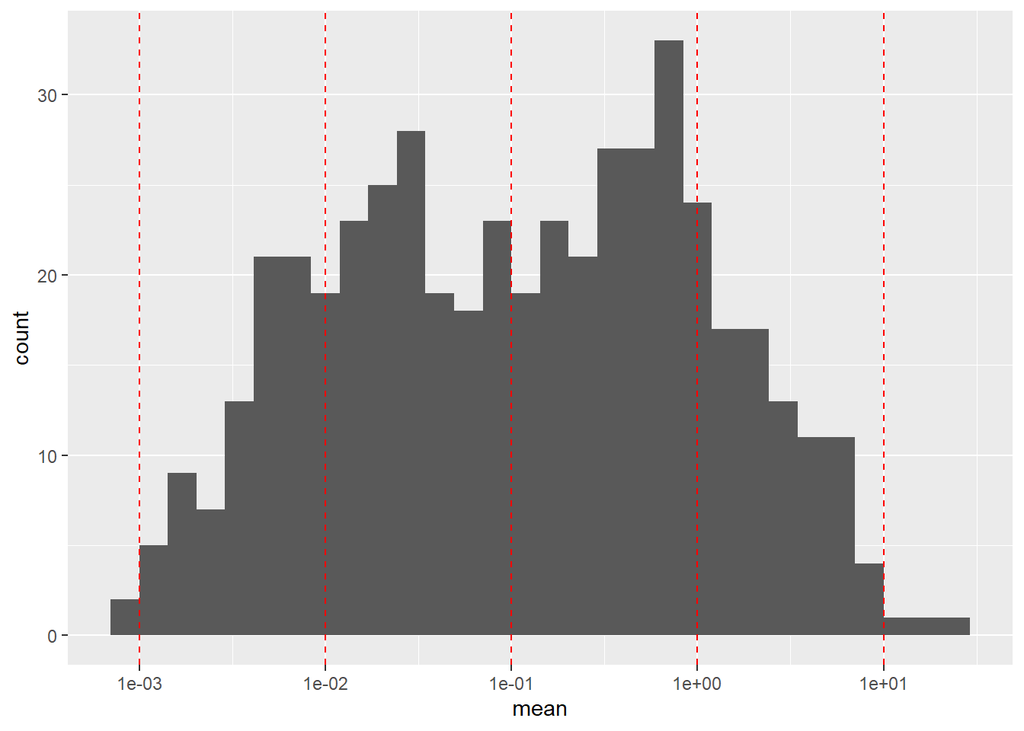

```r
gene_md <- data.frame('mean' = apply(counts,1,mean),
                      row.names = rownames(spat))

gene_md$group <- ifelse(gene_md$mean < .001,'< 0.001',
                        ifelse(gene_md$mean < .01, '< 0.01',
                               ifelse(gene_md$mean < 0.1 , '< 0.1',
                                      ifelse(gene_md$mean < 1,'< 1',
                                             ifelse(gene_md$mean < 10,'< 10', '> 10')))))

ggplot(gene_md, aes(x = mean)) +
  geom_histogram() +
  geom_vline(xintercept = c(.001,.01,.1,1,10), colour = 'red', linetype = 2) +
  scale_x_log10()
```

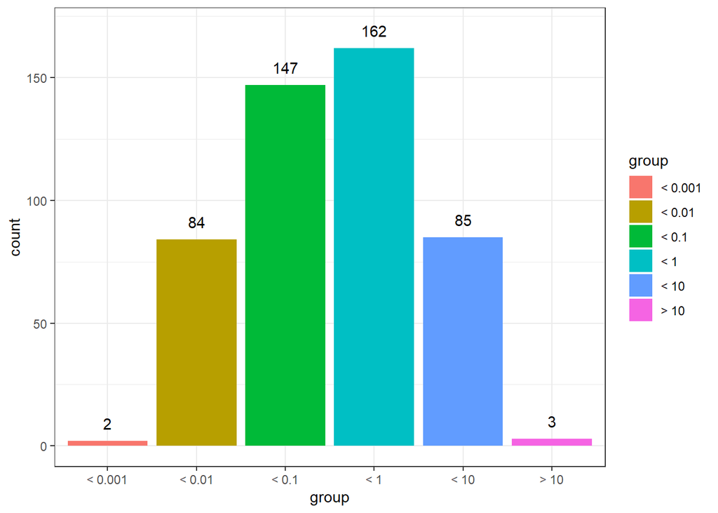

```r
ggplot(gene_md, aes(x = group, fill = group)) +
  geom_bar() +
  ylim(0,170) +
  theme_bw() +
  geom_text(stat = 'count', aes(label = after_stat(count)), vjust = -1)
```

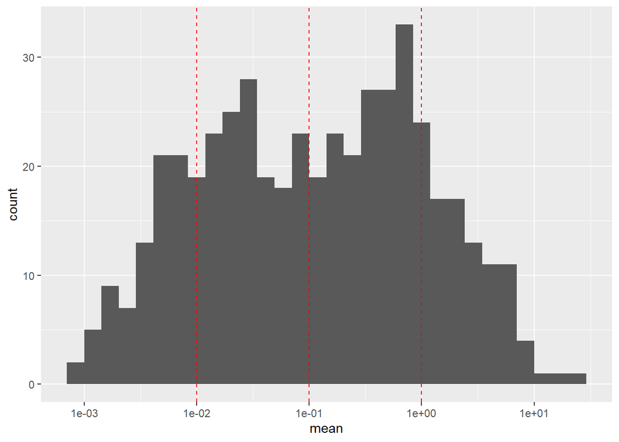

```r
gene_md$group <- ifelse(gene_md$mean < .01, '< 0.01',
                             ifelse(gene_md$mean < 0.1 , '< 0.1',
                                    ifelse(gene_md$mean < 1,'< 1','> 1')))

ggplot(gene_md, aes(x = mean)) +
  geom_histogram() +
  geom_vline(xintercept = c(.01,.1,1), colour = 'red', linetype = 2) +
  scale_x_log10()
```

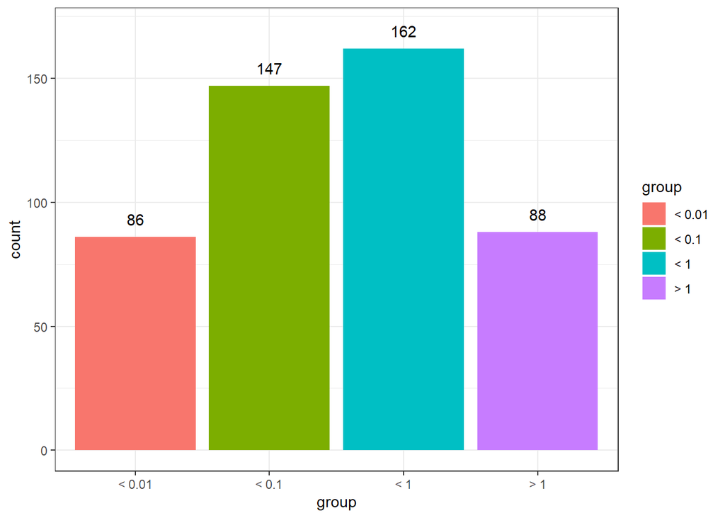

```r
colors_ <- scales::hue_pal()(4)
ggplot(gene_md, aes(x = group, fill = group)) +
  geom_bar() +
  scale_fill_manual(values = colors_) +
  ylim(0,170) +
  theme_bw() +
  geom_text(stat = 'count', aes(label = after_stat(count)), vjust = -1)
```

```r
names(colors_) <- levels(as.factor(gene_md$group))
```

Doesn’t look the same, but I think these cutoffs could work for the demo.

## 8.3 1C

```r
cnts <- as.data.frame(counts)

plot_list <- list()
for (i in levels(as.factor(gene_md$group))){
  print(i)

  p <- cnts[rownames(gene_md[gene_md$group == i,]),]

  colnames(p) <- paste0(colnames(p), '_', spat$nCount_RNA)
  p <- reshape2::melt(as.matrix(p))
  p[,c('cell','nCount')] <- tstrsplit(p$Var2, '_')
  p$nCount <- as.numeric(p$nCount)

  plot_list[[i]] <- ggplot(p, aes(x= nCount, y = value)) +
    geom_smooth(colour = 'black', fill = colors_[i]) +
    theme_bw() +
    ylab('Gene count') +
    ggtitle(paste0("Group ", i, " genes"))
}
```

```
## [1] "< 0.01"
## [1] "< 0.1"
## [1] "< 1"
## [1] "> 1"
```

```r
# plot_list[["< 0.01"]]
```

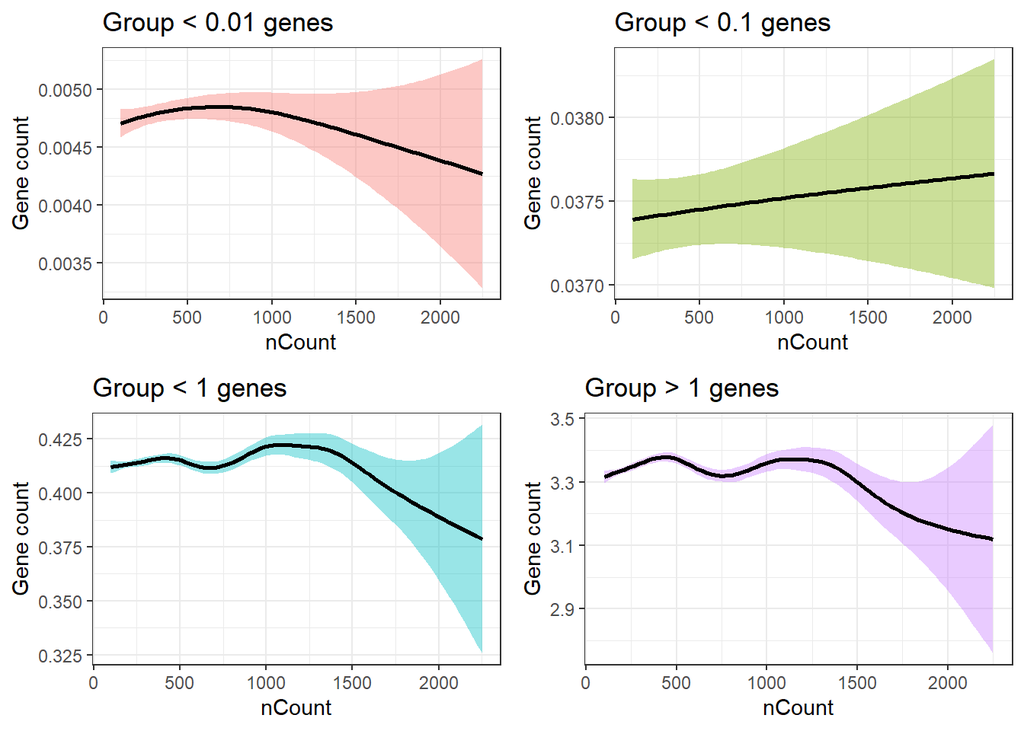

```r
library(ggpubr)

ggarrange(plotlist = plot_list, nrow = 2, ncol = 2)
```

## 8.4 1D

```r
cnts <- as.data.frame(spat@assays$RNA@scale.data)

plot_list <- list()
for (i in levels(as.factor(gene_md$group))){
  print(i)

  p <- cnts[rownames(gene_md[gene_md$group == i,]),]

  colnames(p) <- paste0(colnames(p), '_', spat$nCount_RNA)
  p <- reshape2::melt(as.matrix(p))
  p[,c('cell','nCount')] <- tstrsplit(p$Var2, '_')
  p$nCount <- as.numeric(p$nCount)

  plot_list[[i]] <- ggplot(p, aes(x= nCount, y = value)) +
    geom_smooth(colour = 'black', fill = colors_[i]) +
    theme_bw() +
    ylab('Scaled log-norm expression') +
    ggtitle(paste0("Group ", i, " genes"))
}
```

```
## [1] "< 0.01"
## [1] "< 0.1"
## [1] "< 1"
## [1] "> 1"
```

```r
# plot_list[["< 0.01"]]
```

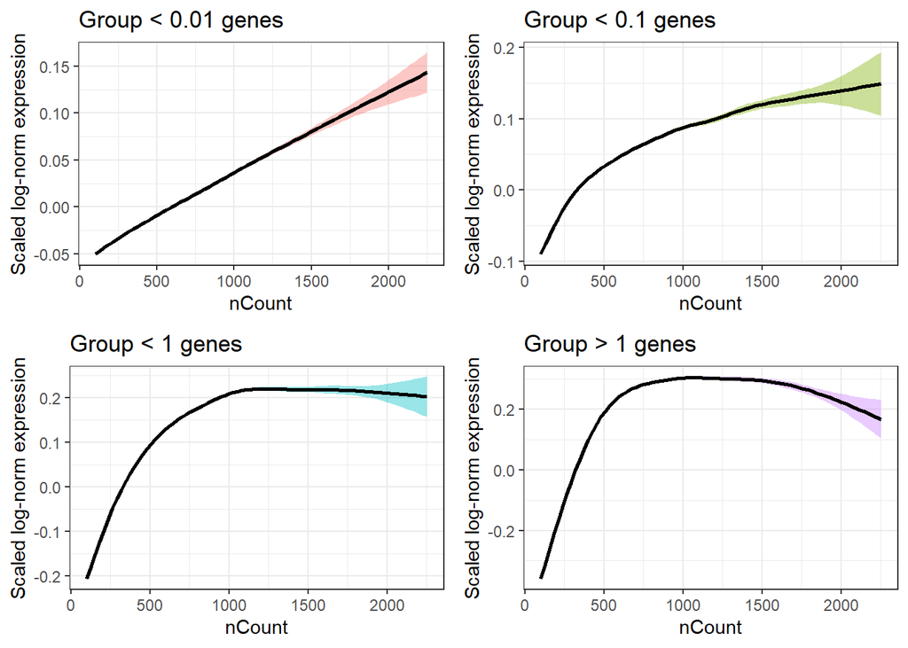

```r
ggarrange(plotlist = plot_list, nrow = 2, ncol = 2)
```

## 8.5 1E

```r
spat$quartile <- cut(spat$nCount_RNA,
                     quantile(spat$nCount_RNA, probs = seq(0,1,.2)),
                     include.lowest = TRUE, labels = F)

# quantile(spat$nCount_RNA)
# ggplot(spat@meta.data, aes(x = nCount_RNA, y = quartile)) +
#   geom_point()
```

```r
cnts <- as.data.frame(spat@assays$RNA@counts)
gene_md$var <- apply(counts,1,var)
gene_md_full <- gene_md
# gene_md
template <- gene_md[,c('mean','group')]

spat$quartile <- as.factor(spat$quartile)

for (i in 1:5){
  df <- cnts[,rownames(spat@meta.data[spat$quartile == i,])]

  gene_md[,paste0('var_group_',i)] <- apply(df,1,var)
}

df <- gene_md[,grepl('var_', colnames(gene_md))]
rownames(df) <- paste0(rownames(df),'_',rowSums(df),'_',gene_md$group)

df <- reshape2::melt(as.matrix(df))

df[,c('gene','var_sum','gene_group')] <- tstrsplit(df$Var1,'_')

df$cell_group <- tstrsplit(df$Var2,'_', keep = 3)[[1]]
df$var_sum <- as.numeric(df$var_sum)
df$var_perc <- df$value / df$var_sum

table(df$gene_group)
```

```
##
## < 0.01  < 0.1    < 1    > 1
##    430    735    810    440
```

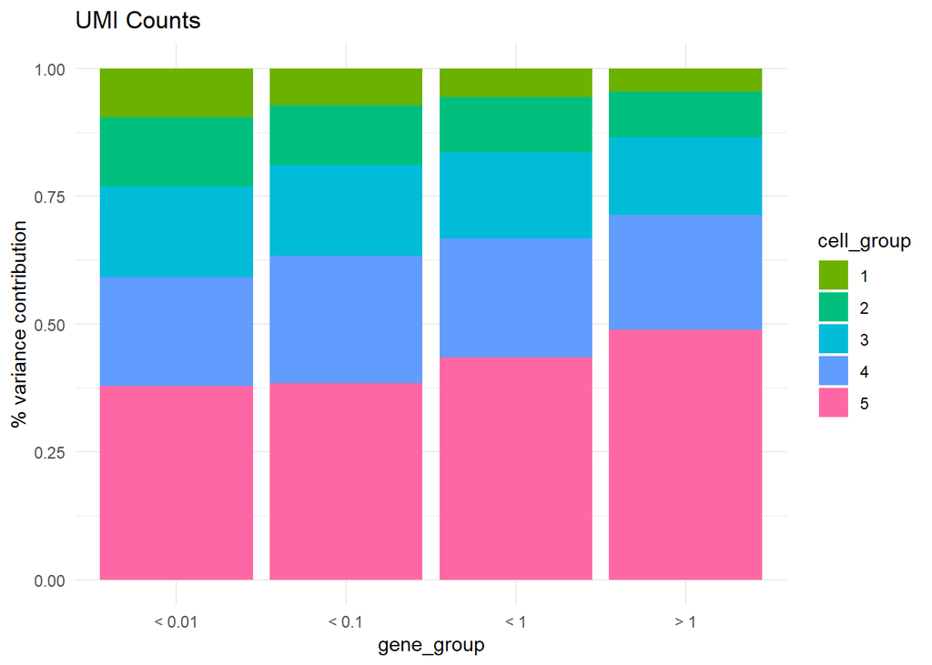

```r
# ggplot(df, aes(x = gene_group, y = var_perc, group = cell_group,
#                fill = cell_group)) +
#   geom_bar(stat = 'identity')

df2 <- merge(df, as.data.frame(table(df$gene_group)), by.x = 'gene_group',
             by.y = 'Var1')

df2$var_perc_new <- df2$var_perc / df2$Freq *5

ggplot(df2, aes(x = gene_group, y = var_perc_new, group = cell_group,
               fill = cell_group)) +
  scale_fill_manual(values = scales::hue_pal()(15)[c(5,7,9,11,15)]) +
  geom_bar(stat = 'identity') +
  ggtitle('UMI Counts') + theme_minimal() +
  ylab('% variance contribution')
```

```r
plot_list <- list()

plot_list[[1]] <- ggplot(df2, aes(x = gene_group, y = var_perc_new, group = cell_group,
               fill = cell_group)) +
  scale_fill_manual(values = scales::hue_pal()(15)[c(5,7,9,11,15)]) +
  geom_bar(stat = 'identity') +
  ggtitle('UMI Counts') + theme_minimal() +
  ylab('% variance contribution')
```

```r
cnts <- as.data.frame(spat@assays$RNA@data)
# gene_md$var <- apply(counts,1,var)
gene_md_full <- gene_md
# gene_md
template <- gene_md[,c('mean','group')]

spat$quartile <- as.factor(spat$quartile)

for (i in 1:5){
  df <- cnts[,rownames(spat@meta.data[spat$quartile == i,])]

  gene_md[,paste0('var2_group_',i)] <- apply(df,1,var)
}

df <- gene_md[,grepl('var2_', colnames(gene_md))]
rownames(df) <- paste0(rownames(df),'_',rowSums(df),'_',gene_md$group)

df <- reshape2::melt(as.matrix(df))

df[,c('gene','var_sum','gene_group')] <- tstrsplit(df$Var1,'_')

df$cell_group <- tstrsplit(df$Var2,'_', keep = 3)[[1]]
df$var_sum <- as.numeric(df$var_sum)
df$var_perc <- df$value / df$var_sum

table(df$gene_group)
```

```
##
## < 0.01  < 0.1    < 1    > 1
##    430    735    810    440
```

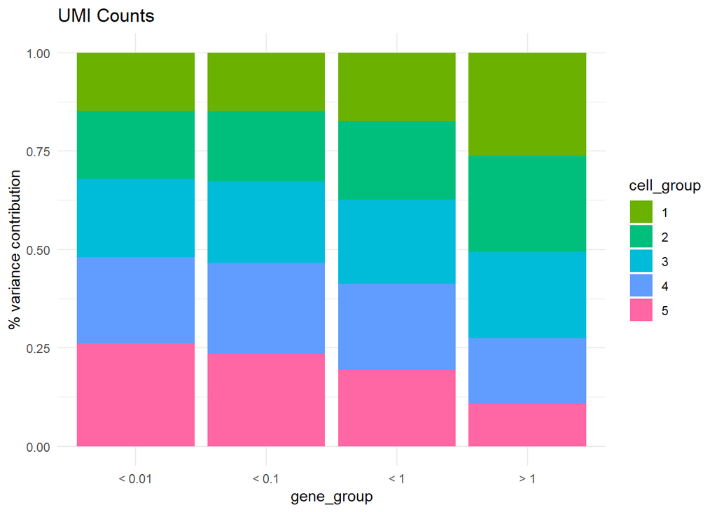

```r
# ggplot(df, aes(x = gene_group, y = var_perc, group = cell_group,
#                fill = cell_group)) +
#   geom_bar(stat = 'identity')

df2 <- merge(df, as.data.frame(table(df$gene_group)), by.x = 'gene_group',
             by.y = 'Var1')

df2$var_perc_new <- df2$var_perc / df2$Freq *5

ggplot(df2, aes(x = gene_group, y = var_perc_new, group = cell_group,
               fill = cell_group)) +
  scale_fill_manual(values = scales::hue_pal()(15)[c(5,7,9,11,15)]) +
  geom_bar(stat = 'identity') +
  ggtitle('UMI Counts') + theme_minimal() +
  ylab('% variance contribution')
```

```r
plot_list[[2]] <- ggplot(df2, aes(x = gene_group, y = var_perc_new, group = cell_group,
               fill = cell_group)) +
  scale_fill_manual(values = scales::hue_pal()(15)[c(5,7,9,11,15)]) +
  geom_bar(stat = 'identity') +
  ggtitle('UMI Counts') + theme_minimal() +
  ylab('% variance contribution')
```

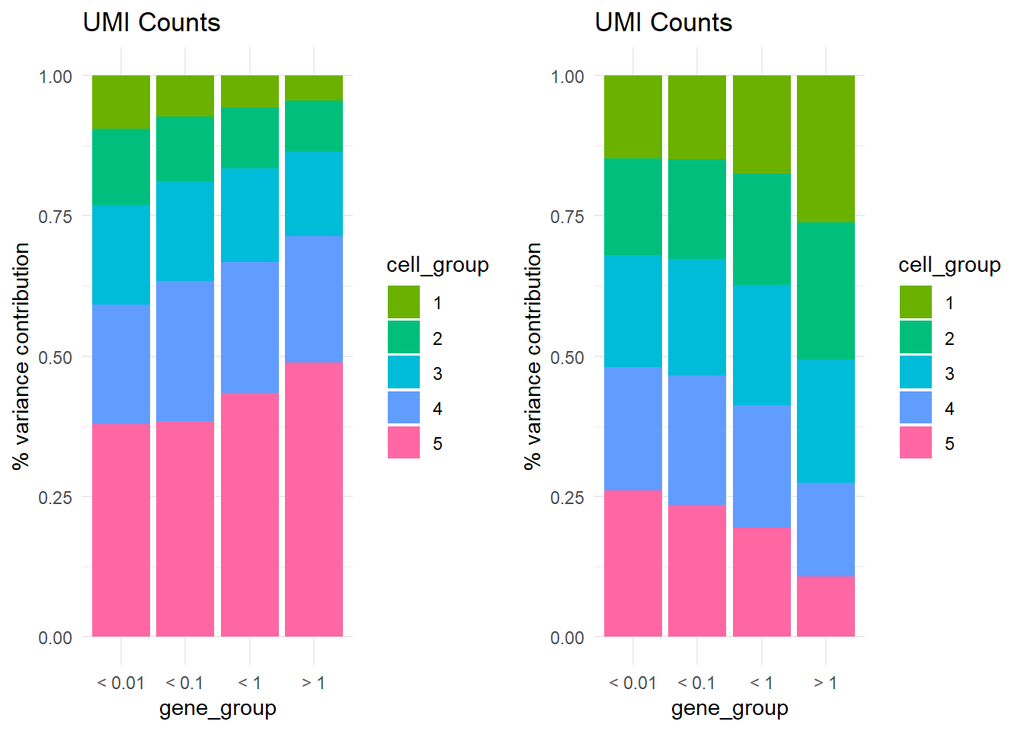

```r
ggarrange(plotlist = plot_list, ncol = 2)
```

## 8.6 3A

```r
cnts <- as.data.frame(spat@assays$SCT@scale.data)

plot_list <- list()
for (i in levels(as.factor(gene_md$group))){
  print(i)

  p <- cnts[rownames(gene_md[gene_md$group == i,]),]

  colnames(p) <- paste0(colnames(p), '_', spat$nCount_RNA)
  p <- reshape2::melt(as.matrix(p))
  p[,c('cell','nCount')] <- tstrsplit(p$Var2, '_')
  p$nCount <- as.numeric(p$nCount)

  plot_list[[i]] <- ggplot(p, aes(x= nCount, y = value)) +
    geom_smooth(colour = 'black', fill = colors_[i]) +
    theme_bw() +
    ylab('Scaled log-norm expression') +
    ggtitle(paste0("Group ", i, " genes"))
}
```

```
## [1] "< 0.01"
## [1] "< 0.1"
## [1] "< 1"
## [1] "> 1"
```

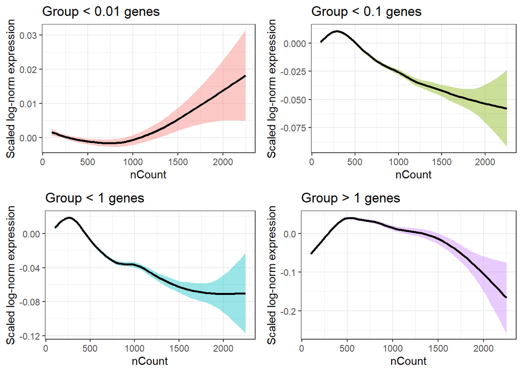

```r
ggarrange(plotlist = plot_list, ncol = 2, nrow = 2)
```

## 8.7 3B

```r
cnts <- as.data.frame(spat@assays$SCT@scale.data)
# gene_md$var <- apply(counts,1,var)
gene_md_full <- gene_md
gene_md <- gene_md[rownames(cnts),]
template <- gene_md[,c('mean','group')]

spat$quartile <- as.factor(spat$quartile)

for (i in 1:5){
  df <- cnts[rownames(cnts),rownames(spat@meta.data[spat$quartile == i,])]

  gene_md[,paste0('var2_group_',i)] <- apply(df,1,var)
}

df <- gene_md[,grepl('var2_', colnames(gene_md))]
rownames(df) <- paste0(rownames(df),'_',rowSums(df),'_',gene_md$group)

df <- reshape2::melt(as.matrix(df))

df[,c('gene','var_sum','gene_group')] <- tstrsplit(df$Var1,'_')

df$cell_group <- tstrsplit(df$Var2,'_', keep = 3)[[1]]
df$var_sum <- as.numeric(df$var_sum)
df$var_perc <- df$value / df$var_sum

table(df$gene_group)
```

```
##
## < 0.01  < 0.1    < 1    > 1
##    430    735    810    440
```

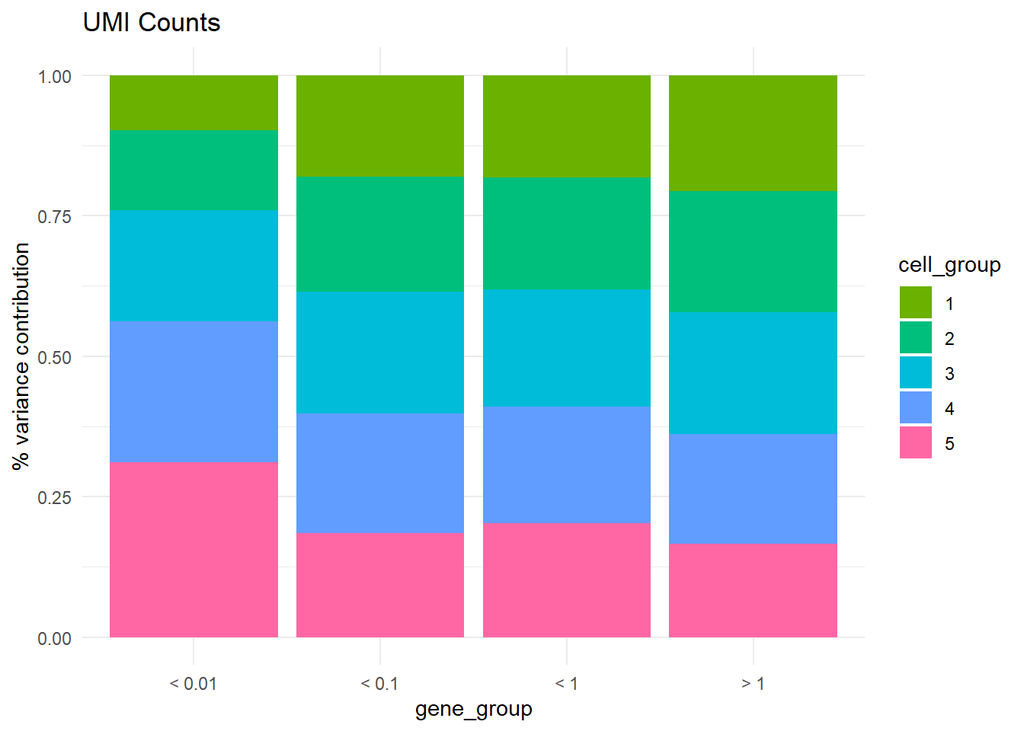

```r
# ggplot(df, aes(x = gene_group, y = var_perc, group = cell_group,
#                fill = cell_group)) +
#   geom_bar(stat = 'identity')

df2 <- merge(df, as.data.frame(table(df$gene_group)), by.x = 'gene_group',
             by.y = 'Var1')

df2$var_perc_new <- df2$var_perc / df2$Freq *5

ggplot(df2, aes(x = gene_group, y = var_perc_new, group = cell_group,
               fill = cell_group)) +
  scale_fill_manual(values = scales::hue_pal()(15)[c(5,7,9,11,15)]) +
  geom_bar(stat = 'identity') +
  ggtitle('UMI Counts') + theme_minimal() +
  ylab('% variance contribution')
```

## 8.8 3C

```r
plot_list <- list()
```

```r
cnts <- as.data.frame(spat@assays$RNA@data)
gene_md <- gene_md_full

x <- t(cnts)
# dim(x)

cor_ <- as.data.frame(cor(x, spat$nCount_RNA, method = 'pearson'))

# rownames(gene_md)[!(rownames(gene_md) %in% rownames(cor_))]

cor_$gene_group <- gene_md[rownames(cor_),]$group

plot_list[[1]] <- ggplot(cor_, aes(x = gene_group, y = V1, fill = gene_group)) +
  geom_violin(scale = 'width') +
  theme_bw() +
  ylim(-.25,.5) +
  ggtitle('Log-norm expression') +
  ylab('Correlation with nCount') +
  geom_hline(yintercept = 0, colour = 'black', size = 2, linetype = 2)
cnts <- as.data.frame(spat@assays$SCT@scale.data)
gene_md <- gene_md_full

x <- t(cnts)
# dim(x)

cor_ <- as.data.frame(cor(x, spat$nCount_RNA, method = 'pearson'))

# rownames(gene_md)[!(rownames(gene_md) %in% rownames(cor_))]

cor_$gene_group <- gene_md[rownames(cor_),]$group

plot_list[[2]] <- ggplot(cor_, aes(x = gene_group, y = V1, fill = gene_group)) +
  geom_violin(scale = 'width') +
  theme_bw() +
  ylim(-.25,.5) +
  ggtitle('Pearson residuals') +
  ylab('Correlation with nCount') +
  geom_hline(yintercept = 0, colour = 'black', size = 2, linetype = 2)
# plot_list[[2]]
```

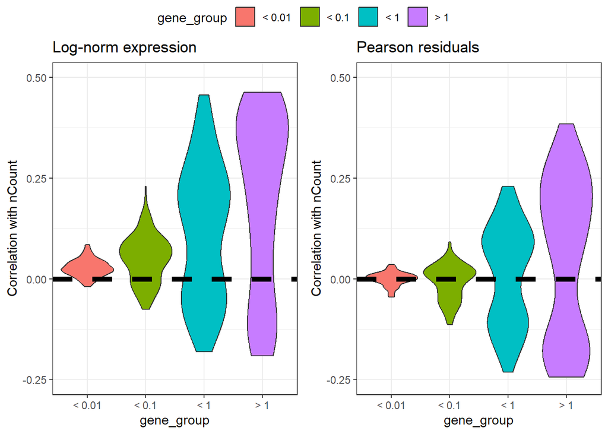

```r
ggarrange(plotlist = plot_list, ncol = 2, common.legend = T)
```